# Fitbit Daily Activity

Jose Juan Lopez

2024-01-25

## Setting up my environment

Load libraries.

```r
library(tidyverse)
```

```r
library(dplyr)
library(ggplot2)
library(tidyr)
library(here)
library(skimr)
library(janitor)
library(readr)
library(scales)
library(gridExtra)
library(lubridate)
library(grid)
library(gridExtra)
library(magrittr)
library(patchwork)
```

## Read documents

In this analysis I choose to analyze:

- DailyActivityMerged_2020_05_12.csv
- DailyCaloriesMerged_2020_05_12.csv
- DailyIntensitiesMerged_2020_05_12.csv
- DailyStepsMerged_2020_05_12.csv
- SleepDayMerged_2020_05_12.csv

I consider these databases to help to understand the behavior of people’s devices and identify the new way which needs **marketing strategy** of Bellabeat.

### Showing daily activity data

```r
dActivity <- read.csv('~/Documents/Data Analyst/Bellabeat/Q2-Fitbit-Data/DailyActivityMerged_2020_05_12.csv')
head(dActivity)
```

|  | Id | ActivityDate | TotalSteps | TotalDistance | TrackerDistance | LoggedActivitiesDistance | VeryActiveDistance | ModeratelyActiveDistance | LightActiveDistance | SedentaryActiveDistance | VeryActiveMinutes | FairlyActiveMinutes | LightlyActiveMinutes | SedentaryMinutes | Calories |
| --- | --- | --- | --- | --- | --- | --- | --- | --- | --- | --- | --- | --- | --- | --- | --- |
| 1 | 1503960366 | 4/12/2016 | 13162 | 8.50 | 8.50 | 0 | 1.88 | 0.55 | 6.06 | 0 | 25 | 13 | 328 | 728 | 1985 |
| 2 | 1503960366 | 4/13/2016 | 10735 | 6.97 | 6.97 | 0 | 1.57 | 0.69 | 4.71 | 0 | 21 | 19 | 217 | 776 | 1797 |
| 3 | 1503960366 | 4/14/2016 | 10460 | 6.74 | 6.74 | 0 | 2.44 | 0.40 | 3.91 | 0 | 30 | 11 | 181 | 1218 | 1776 |
| 4 | 1503960366 | 4/15/2016 | 9762 | 6.28 | 6.28 | 0 | 2.14 | 1.26 | 2.83 | 0 | 29 | 34 | 209 | 726 | 1745 |
| 5 | 1503960366 | 4/16/2016 | 12669 | 8.16 | 8.16 | 0 | 2.71 | 0.41 | 5.04 | 0 | 36 | 10 | 221 | 773 | 1863 |
| 6 | 1503960366 | 4/17/2016 | 9705 | 6.48 | 6.48 | 0 | 3.19 | 0.78 | 2.51 | 0 | 38 | 20 | 164 | 539 | 1728 |

```r
str(dActivity)
```

```
## 'data.frame':    940 obs. of  15 variables:
##  $ Id                      : num  1.5e+09 1.5e+09 1.5e+09 1.5e+09 1.5e+09 ...
##  $ ActivityDate            : chr  "4/12/2016" "4/13/2016" "4/14/2016" "4/15/2016" ...
##  $ TotalSteps              : int  13162 10735 10460 9762 12669 9705 13019 15506 10544 9819 ...
##  $ TotalDistance           : num  8.5 6.97 6.74 6.28 8.16 ...
##  $ TrackerDistance         : num  8.5 6.97 6.74 6.28 8.16 ...
##  $ LoggedActivitiesDistance: num  0 0 0 0 0 0 0 0 0 0 ...
##  $ VeryActiveDistance      : num  1.88 1.57 2.44 2.14 2.71 ...
##  $ ModeratelyActiveDistance: num  0.55 0.69 0.4 1.26 0.41 ...
##  $ LightActiveDistance     : num  6.06 4.71 3.91 2.83 5.04 ...
##  $ SedentaryActiveDistance : num  0 0 0 0 0 0 0 0 0 0 ...
##  $ VeryActiveMinutes       : int  25 21 30 29 36 38 42 50 28 19 ...
##  $ FairlyActiveMinutes     : int  13 19 11 34 10 20 16 31 12 8 ...
##  $ LightlyActiveMinutes    : int  328 217 181 209 221 164 233 264 205 211 ...
##  $ SedentaryMinutes        : int  728 776 1218 726 773 539 1149 775 818 838 ...
##  $ Calories                : int  1985 1797 1776 1745 1863 1728 1921 2035 1786 1775 ...
```

```r
colnames(dActivity)
```

```
##  [1] "Id"                       "ActivityDate"
##  [3] "TotalSteps"               "TotalDistance"
##  [5] "TrackerDistance"          "LoggedActivitiesDistance"
##  [7] "VeryActiveDistance"       "ModeratelyActiveDistance"
##  [9] "LightActiveDistance"      "SedentaryActiveDistance"
## [11] "VeryActiveMinutes"        "FairlyActiveMinutes"
## [13] "LightlyActiveMinutes"     "SedentaryMinutes"
## [15] "Calories"
```

### Showing daily calories data

```r
dCalories <- read.csv('~/Documents/Data Analyst/Bellabeat/Q2-Fitbit-Data/DailyCaloriesMerged_2020_05_12.csv')
head(dCalories)
```

|  | Id | ActivityDay | Calories |
| --- | --- | --- | --- |
| 1 | 1503960366 | 4/12/2016 | 1985 |
| 2 | 1503960366 | 4/13/2016 | 1797 |
| 3 | 1503960366 | 4/14/2016 | 1776 |
| 4 | 1503960366 | 4/15/2016 | 1745 |
| 5 | 1503960366 | 4/16/2016 | 1863 |
| 6 | 1503960366 | 4/17/2016 | 1728 |

```r
str(dCalories)
```

```
## 'data.frame':    940 obs. of  3 variables:
##  $ Id         : num  1.5e+09 1.5e+09 1.5e+09 1.5e+09 1.5e+09 ...
##  $ ActivityDay: chr  "4/12/2016" "4/13/2016" "4/14/2016" "4/15/2016" ...
##  $ Calories   : int  1985 1797 1776 1745 1863 1728 1921 2035 1786 1775 ...
```

```r
colnames(dCalories)
```

```
## [1] "Id"          "ActivityDay" "Calories"
```

### Showing daily intensities data

```r
dIntensities <- read.csv('~/Documents/Data Analyst/Bellabeat/Q2-Fitbit-Data/DailyIntensitiesMerged_2020_05_12.csv')
head(dIntensities)
```

|  | Id | ActivityDay | SedentaryMinutes | LightlyActiveMinutes | FairlyActiveMinutes | VeryActiveMinutes | SedentaryActiveDistance | LightActiveDistance | ModeratelyActiveDistance | VeryActiveDistance |
| --- | --- | --- | --- | --- | --- | --- | --- | --- | --- | --- |
| 1 | 1503960366 | 4/12/2016 | 728 | 328 | 13 | 25 | 0 | 6.06 | 0.55 | 1.88 |
| 2 | 1503960366 | 4/13/2016 | 776 | 217 | 19 | 21 | 0 | 4.71 | 0.69 | 1.57 |
| 3 | 1503960366 | 4/14/2016 | 1218 | 181 | 11 | 30 | 0 | 3.91 | 0.40 | 2.44 |
| 4 | 1503960366 | 4/15/2016 | 726 | 209 | 34 | 29 | 0 | 2.83 | 1.26 | 2.14 |
| 5 | 1503960366 | 4/16/2016 | 773 | 221 | 10 | 36 | 0 | 5.04 | 0.41 | 2.71 |
| 6 | 1503960366 | 4/17/2016 | 539 | 164 | 20 | 38 | 0 | 2.51 | 0.78 | 3.19 |

```r
str(dIntensities)
```

```
## 'data.frame':    940 obs. of  10 variables:
##  $ Id                      : num  1.5e+09 1.5e+09 1.5e+09 1.5e+09 1.5e+09 ...
##  $ ActivityDay             : chr  "4/12/2016" "4/13/2016" "4/14/2016" "4/15/2016" ...
##  $ SedentaryMinutes        : int  728 776 1218 726 773 539 1149 775 818 838 ...
##  $ LightlyActiveMinutes    : int  328 217 181 209 221 164 233 264 205 211 ...
##  $ FairlyActiveMinutes     : int  13 19 11 34 10 20 16 31 12 8 ...
##  $ VeryActiveMinutes       : int  25 21 30 29 36 38 42 50 28 19 ...
##  $ SedentaryActiveDistance : num  0 0 0 0 0 0 0 0 0 0 ...
##  $ LightActiveDistance     : num  6.06 4.71 3.91 2.83 5.04 ...
##  $ ModeratelyActiveDistance: num  0.55 0.69 0.4 1.26 0.41 ...
##  $ VeryActiveDistance      : num  1.88 1.57 2.44 2.14 2.71 ...
```

```r
colnames(dIntensities)
```

```
##  [1] "Id"                       "ActivityDay"
##  [3] "SedentaryMinutes"         "LightlyActiveMinutes"
##  [5] "FairlyActiveMinutes"      "VeryActiveMinutes"
##  [7] "SedentaryActiveDistance"  "LightActiveDistance"
##  [9] "ModeratelyActiveDistance" "VeryActiveDistance"
```

### Showing daily steps data

```r
dSteps <- read.csv('~/Documents/Data Analyst/Bellabeat/Q2-Fitbit-Data/DailyStepsMerged_2020_05_12.csv')
head(dSteps)
```

|  | Id | ActivityDay | StepTotal |
| --- | --- | --- | --- |
| 1 | 1503960366 | 4/12/2016 | 13162 |
| 2 | 1503960366 | 4/13/2016 | 10735 |
| 3 | 1503960366 | 4/14/2016 | 10460 |
| 4 | 1503960366 | 4/15/2016 | 9762 |
| 5 | 1503960366 | 4/16/2016 | 12669 |
| 6 | 1503960366 | 4/17/2016 | 9705 |

```r
str(dSteps)
```

```
## 'data.frame':    940 obs. of  3 variables:
##  $ Id         : num  1.5e+09 1.5e+09 1.5e+09 1.5e+09 1.5e+09 ...
##  $ ActivityDay: chr  "4/12/2016" "4/13/2016" "4/14/2016" "4/15/2016" ...
##  $ StepTotal  : int  13162 10735 10460 9762 12669 9705 13019 15506 10544 9819 ...
```

```r
colnames(dSteps)
```

```
## [1] "Id"          "ActivityDay" "StepTotal"
```

### Showing sleep day data

```r
sDay <- read.csv('~/Documents/Data Analyst/Bellabeat/Q2-Fitbit-Data/SleepDayMerged_2020_05_12.csv')
head(sDay)
```

|  | Id | SleepDay | TotalSleepRecords | TotalMinutesAsleep | TotalTimeInBed |
| --- | --- | --- | --- | --- | --- |
| 1 | 1503960366 | 4/12/2016 12:00:00 AM | 1 | 327 | 346 |
| 2 | 1503960366 | 4/13/2016 12:00:00 AM | 2 | 384 | 407 |
| 3 | 1503960366 | 4/15/2016 12:00:00 AM | 1 | 412 | 442 |
| 4 | 1503960366 | 4/16/2016 12:00:00 AM | 2 | 340 | 367 |
| 5 | 1503960366 | 4/17/2016 12:00:00 AM | 1 | 700 | 712 |
| 6 | 1503960366 | 4/19/2016 12:00:00 AM | 1 | 304 | 320 |

```r
str(sDay)
```

```
## 'data.frame':    413 obs. of  5 variables:
##  $ Id                : num  1.5e+09 1.5e+09 1.5e+09 1.5e+09 1.5e+09 ...
##  $ SleepDay          : chr  "4/12/2016 12:00:00 AM" "4/13/2016 12:00:00 AM" "4/15/2016 12:00:00 AM" "4/16/2016 12:00:00 AM" ...
##  $ TotalSleepRecords : int  1 2 1 2 1 1 1 1 1 1 ...
##  $ TotalMinutesAsleep: int  327 384 412 340 700 304 360 325 361 430 ...
##  $ TotalTimeInBed    : int  346 407 442 367 712 320 377 364 384 449 ...
```

```r
colnames(sDay)
```

```
## [1] "Id"                 "SleepDay"           "TotalSleepRecords"
## [4] "TotalMinutesAsleep" "TotalTimeInBed"
```

## Empty Values

After to showing daily users activity, got to search duplicate data for disposal

### Searching duplicate data

```r
sum(duplicated(dActivity))
```

```
## [1] 0
```

```r
sum(duplicated(dCalories))
```

```
## [1] 0
```

```r
sum(duplicated(dIntensities))
```

```
## [1] 0
```

```r
sum(duplicated(dSteps))
```

```
## [1] 0
```

```r
sum(duplicated(sDay))
```

```
## [1] 3
```

```r
sd <- sDay
nrow(dActivity)-sum(complete.cases(dActivity))
```

```
## [1] 0
```

```r
nrow(dCalories)-sum(complete.cases(dCalories))
```

```
## [1] 0
```

```r
nrow(dIntensities)-sum(complete.cases(dIntensities))
```

```
## [1] 0
```

```r
nrow(dSteps)-sum(complete.cases(dSteps))
```

```
## [1] 0
```

```r
nrow(sd)-sum(complete.cases(sd))
```

```
## [1] 0
```

## Format and timetable

Subsequently, activity dates, days and sleep day format will be changed in each of these databases.

### Showing activity date modified at daily activity data

```r
dActivity$ActivityDate <- as.Date (dActivity$ActivityDate, format = "%m/%d/%Y")
head(dActivity)
```

|  | Id | ActivityDate | TotalSteps | TotalDistance | TrackerDistance | LoggedActivitiesDistance | VeryActiveDistance | ModeratelyActiveDistance | LightActiveDistance | SedentaryActiveDistance | VeryActiveMinutes | FairlyActiveMinutes | LightlyActiveMinutes | SedentaryMinutes | Calories |
| --- | --- | --- | --- | --- | --- | --- | --- | --- | --- | --- | --- | --- | --- | --- | --- |
| 1 | 1503960366 | 2016-04-12 | 13162 | 8.50 | 8.50 | 0 | 1.88 | 0.55 | 6.06 | 0 | 25 | 13 | 328 | 728 | 1985 |
| 2 | 1503960366 | 2016-04-13 | 10735 | 6.97 | 6.97 | 0 | 1.57 | 0.69 | 4.71 | 0 | 21 | 19 | 217 | 776 | 1797 |
| 3 | 1503960366 | 2016-04-14 | 10460 | 6.74 | 6.74 | 0 | 2.44 | 0.40 | 3.91 | 0 | 30 | 11 | 181 | 1218 | 1776 |
| 4 | 1503960366 | 2016-04-15 | 9762 | 6.28 | 6.28 | 0 | 2.14 | 1.26 | 2.83 | 0 | 29 | 34 | 209 | 726 | 1745 |
| 5 | 1503960366 | 2016-04-16 | 12669 | 8.16 | 8.16 | 0 | 2.71 | 0.41 | 5.04 | 0 | 36 | 10 | 221 | 773 | 1863 |
| 6 | 1503960366 | 2016-04-17 | 9705 | 6.48 | 6.48 | 0 | 3.19 | 0.78 | 2.51 | 0 | 38 | 20 | 164 | 539 | 1728 |

```r
str(dActivity)
```

```
## 'data.frame':    940 obs. of  15 variables:
##  $ Id                      : num  1.5e+09 1.5e+09 1.5e+09 1.5e+09 1.5e+09 ...
##  $ ActivityDate            : Date, format: "2016-04-12" "2016-04-13" ...
##  $ TotalSteps              : int  13162 10735 10460 9762 12669 9705 13019 15506 10544 9819 ...
##  $ TotalDistance           : num  8.5 6.97 6.74 6.28 8.16 ...
##  $ TrackerDistance         : num  8.5 6.97 6.74 6.28 8.16 ...
##  $ LoggedActivitiesDistance: num  0 0 0 0 0 0 0 0 0 0 ...
##  $ VeryActiveDistance      : num  1.88 1.57 2.44 2.14 2.71 ...
##  $ ModeratelyActiveDistance: num  0.55 0.69 0.4 1.26 0.41 ...
##  $ LightActiveDistance     : num  6.06 4.71 3.91 2.83 5.04 ...
##  $ SedentaryActiveDistance : num  0 0 0 0 0 0 0 0 0 0 ...
##  $ VeryActiveMinutes       : int  25 21 30 29 36 38 42 50 28 19 ...
##  $ FairlyActiveMinutes     : int  13 19 11 34 10 20 16 31 12 8 ...
##  $ LightlyActiveMinutes    : int  328 217 181 209 221 164 233 264 205 211 ...
##  $ SedentaryMinutes        : int  728 776 1218 726 773 539 1149 775 818 838 ...
##  $ Calories                : int  1985 1797 1776 1745 1863 1728 1921 2035 1786 1775 ...
```

### Showing activity date modified at daily calories data

```r
dCalories$ActivityDay <- as.Date (dCalories$ActivityDay, format = "%m/%d/%Y")
head(dCalories)
```

|  | Id | ActivityDay | Calories |
| --- | --- | --- | --- |
| 1 | 1503960366 | 2016-04-12 | 1985 |
| 2 | 1503960366 | 2016-04-13 | 1797 |
| 3 | 1503960366 | 2016-04-14 | 1776 |
| 4 | 1503960366 | 2016-04-15 | 1745 |
| 5 | 1503960366 | 2016-04-16 | 1863 |
| 6 | 1503960366 | 2016-04-17 | 1728 |

```r
str(dCalories)
```

```
## 'data.frame':    940 obs. of  3 variables:
##  $ Id         : num  1.5e+09 1.5e+09 1.5e+09 1.5e+09 1.5e+09 ...
##  $ ActivityDay: Date, format: "2016-04-12" "2016-04-13" ...
##  $ Calories   : int  1985 1797 1776 1745 1863 1728 1921 2035 1786 1775 ...
```

### Showing activity date modified at daily intensities data

```r
dIntensities$ActivityDay <- as.Date (dIntensities$ActivityDay, format = "%m/%d/%Y")
head(dIntensities)
```

|  | Id | ActivityDay | SedentaryMinutes | LightlyActiveMinutes | FairlyActiveMinutes | VeryActiveMinutes | SedentaryActiveDistance | LightActiveDistance | ModeratelyActiveDistance | VeryActiveDistance |
| --- | --- | --- | --- | --- | --- | --- | --- | --- | --- | --- |
| 1 | 1503960366 | 2016-04-12 | 728 | 328 | 13 | 25 | 0 | 6.06 | 0.55 | 1.88 |
| 2 | 1503960366 | 2016-04-13 | 776 | 217 | 19 | 21 | 0 | 4.71 | 0.69 | 1.57 |
| 3 | 1503960366 | 2016-04-14 | 1218 | 181 | 11 | 30 | 0 | 3.91 | 0.40 | 2.44 |
| 4 | 1503960366 | 2016-04-15 | 726 | 209 | 34 | 29 | 0 | 2.83 | 1.26 | 2.14 |
| 5 | 1503960366 | 2016-04-16 | 773 | 221 | 10 | 36 | 0 | 5.04 | 0.41 | 2.71 |
| 6 | 1503960366 | 2016-04-17 | 539 | 164 | 20 | 38 | 0 | 2.51 | 0.78 | 3.19 |

```r
str(dIntensities)
```

```
## 'data.frame':    940 obs. of  10 variables:
##  $ Id                      : num  1.5e+09 1.5e+09 1.5e+09 1.5e+09 1.5e+09 ...
##  $ ActivityDay             : Date, format: "2016-04-12" "2016-04-13" ...
##  $ SedentaryMinutes        : int  728 776 1218 726 773 539 1149 775 818 838 ...
##  $ LightlyActiveMinutes    : int  328 217 181 209 221 164 233 264 205 211 ...
##  $ FairlyActiveMinutes     : int  13 19 11 34 10 20 16 31 12 8 ...
##  $ VeryActiveMinutes       : int  25 21 30 29 36 38 42 50 28 19 ...
##  $ SedentaryActiveDistance : num  0 0 0 0 0 0 0 0 0 0 ...
##  $ LightActiveDistance     : num  6.06 4.71 3.91 2.83 5.04 ...
##  $ ModeratelyActiveDistance: num  0.55 0.69 0.4 1.26 0.41 ...
##  $ VeryActiveDistance      : num  1.88 1.57 2.44 2.14 2.71 ...
```

### Showing activity date modified at daily steps data

```r
dSteps$ActivityDay <- as.Date (dSteps$ActivityDay, format = "%m/%d/%Y")
head(dSteps)
```

|  | Id | ActivityDay | StepTotal |
| --- | --- | --- | --- |
| 1 | 1503960366 | 2016-04-12 | 13162 |
| 2 | 1503960366 | 2016-04-13 | 10735 |
| 3 | 1503960366 | 2016-04-14 | 10460 |
| 4 | 1503960366 | 2016-04-15 | 9762 |
| 5 | 1503960366 | 2016-04-16 | 12669 |
| 6 | 1503960366 | 2016-04-17 | 9705 |

```r
str(dSteps)
```

```
## 'data.frame':    940 obs. of  3 variables:
##  $ Id         : num  1.5e+09 1.5e+09 1.5e+09 1.5e+09 1.5e+09 ...
##  $ ActivityDay: Date, format: "2016-04-12" "2016-04-13" ...
##  $ StepTotal  : int  13162 10735 10460 9762 12669 9705 13019 15506 10544 9819 ...
```

### Showing activity date modified at sleep day data

```r
sDay$SleepDay <- sDay$SleepDay %>%
  as.POSIXct(format = "%m/%d/%Y %I:%M:%S %p") %>%
  as.Date(format = "%m/%d/%Y %I:%M:%S %p")
head(sDay)
```

|  | Id | SleepDay | TotalSleepRecords | TotalMinutesAsleep | TotalTimeInBed |
| --- | --- | --- | --- | --- | --- |
| 1 | 1503960366 | 2016-04-12 | 1 | 327 | 346 |
| 2 | 1503960366 | 2016-04-13 | 2 | 384 | 407 |
| 3 | 1503960366 | 2016-04-15 | 1 | 412 | 442 |
| 4 | 1503960366 | 2016-04-16 | 2 | 340 | 367 |
| 5 | 1503960366 | 2016-04-17 | 1 | 700 | 712 |
| 6 | 1503960366 | 2016-04-19 | 1 | 304 | 320 |

```r
str(sDay)
```

```
## 'data.frame':    413 obs. of  5 variables:
##  $ Id                : num  1.5e+09 1.5e+09 1.5e+09 1.5e+09 1.5e+09 ...
##  $ SleepDay          : Date, format: "2016-04-12" "2016-04-13" ...
##  $ TotalSleepRecords : int  1 2 1 2 1 1 1 1 1 1 ...
##  $ TotalMinutesAsleep: int  327 384 412 340 700 304 360 325 361 430 ...
##  $ TotalTimeInBed    : int  346 407 442 367 712 320 377 364 384 449 ...
```

## Analysis

Once the data has been cleaned, the investigation continues to find the data that will help to create visualizations for decision-making.

First, this begins with a participants count to see if they are participating in each report, otherwise, any reports that don’t have all parties will be ruled out because they hampered the analysis results

```r
n_distinct(dActivity$Id)
```

```
## [1] 33
```

```r
n_distinct(dCalories$Id)
```

```
## [1] 33
```

```r
n_distinct(dIntensities$Id)
```

```
## [1] 33
```

```r
n_distinct(dSteps$Id)
```

```
## [1] 33
```

```r
n_distinct(sDay$Id)
```

```
## [1] 24
```

In this case, the document *SleepDayMerged_2020_05_12* is incomplete and will not be used in the analysis.

## Data frames

Then, I started to get the data frames of each daily user activity.

### Showing daily activity data frame

```r
dActivity %>%
select(TotalSteps, TotalDistance, VeryActiveDistance, ModeratelyActiveDistance, LightActiveDistance, SedentaryActiveDistance, SedentaryMinutes, LightActiveDistance, VeryActiveMinutes, FairlyActiveMinutes, LightlyActiveMinutes, SedentaryMinutes) %>% summary ()
```

```
##    TotalSteps    TotalDistance    VeryActiveDistance ModeratelyActiveDistance
##  Min.   :    0   Min.   : 0.000   Min.   : 0.000     Min.   :0.0000
##  1st Qu.: 3790   1st Qu.: 2.620   1st Qu.: 0.000     1st Qu.:0.0000
##  Median : 7406   Median : 5.245   Median : 0.210     Median :0.2400
##  Mean   : 7638   Mean   : 5.490   Mean   : 1.503     Mean   :0.5675
##  3rd Qu.:10727   3rd Qu.: 7.713   3rd Qu.: 2.053     3rd Qu.:0.8000
##  Max.   :36019   Max.   :28.030   Max.   :21.920     Max.   :6.4800
##  LightActiveDistance SedentaryActiveDistance SedentaryMinutes VeryActiveMinutes
##  Min.   : 0.000      Min.   :0.000000        Min.   :   0.0   Min.   :  0.00
##  1st Qu.: 1.945      1st Qu.:0.000000        1st Qu.: 729.8   1st Qu.:  0.00
##  Median : 3.365      Median :0.000000        Median :1057.5   Median :  4.00
##  Mean   : 3.341      Mean   :0.001606        Mean   : 991.2   Mean   : 21.16
##  3rd Qu.: 4.782      3rd Qu.:0.000000        3rd Qu.:1229.5   3rd Qu.: 32.00
##  Max.   :10.710      Max.   :0.110000        Max.   :1440.0   Max.   :210.00
##  FairlyActiveMinutes LightlyActiveMinutes
##  Min.   :  0.00      Min.   :  0.0
##  1st Qu.:  0.00      1st Qu.:127.0
##  Median :  6.00      Median :199.0
##  Mean   : 13.56      Mean   :192.8
##  3rd Qu.: 19.00      3rd Qu.:264.0
##  Max.   :143.00      Max.   :518.0
```

### Showing daily calories data frame

```r
dCalories %>%
 select(Calories) %>%
 summary()
```

```
##     Calories
##  Min.   :   0
##  1st Qu.:1828
##  Median :2134
##  Mean   :2304
##  3rd Qu.:2793
##  Max.   :4900
```

### Showing daily intensities data frame

```r
dIntensities %>%
 select(SedentaryMinutes, LightlyActiveMinutes, FairlyActiveMinutes, VeryActiveMinutes)%>%
 summary()
```

```
##  SedentaryMinutes LightlyActiveMinutes FairlyActiveMinutes VeryActiveMinutes
##  Min.   :   0.0   Min.   :  0.0        Min.   :  0.00      Min.   :  0.00
##  1st Qu.: 729.8   1st Qu.:127.0        1st Qu.:  0.00      1st Qu.:  0.00
##  Median :1057.5   Median :199.0        Median :  6.00      Median :  4.00
##  Mean   : 991.2   Mean   :192.8        Mean   : 13.56      Mean   : 21.16
##  3rd Qu.:1229.5   3rd Qu.:264.0        3rd Qu.: 19.00      3rd Qu.: 32.00
##  Max.   :1440.0   Max.   :518.0        Max.   :143.00      Max.   :210.00
```

### Showing daily steps data frame

```r
dSteps %>%
 select(StepTotal)%>%
 summary()
```

```
##    StepTotal
##  Min.   :    0
##  1st Qu.: 3790
##  Median : 7406
##  Mean   : 7638
##  3rd Qu.:10727
##  Max.   :36019
```

### Construction data

As soon as the results of the data frame, are made a comparison with daily calories and daily steps about daily activity

```r
datacs <- merge(dCalories,dSteps)
head(datacs)
```

|  | Id | ActivityDay | Calories | StepTotal |
| --- | --- | --- | --- | --- |
| 1 | 1503960366 | 2016-04-12 | 1985 | 13162 |
| 2 | 1503960366 | 2016-04-13 | 1797 | 10735 |
| 3 | 1503960366 | 2016-04-14 | 1776 | 10460 |
| 4 | 1503960366 | 2016-04-15 | 1745 | 9762 |
| 5 | 1503960366 | 2016-04-16 | 1863 | 12669 |
| 6 | 1503960366 | 2016-04-17 | 1728 | 9705 |

```r
str(datacs)
```

```
## 'data.frame':    940 obs. of  4 variables:
##  $ Id         : num  1.5e+09 1.5e+09 1.5e+09 1.5e+09 1.5e+09 ...
##  $ ActivityDay: Date, format: "2016-04-12" "2016-04-13" ...
##  $ Calories   : int  1985 1797 1776 1745 1863 1728 1921 2035 1786 1775 ...
##  $ StepTotal  : int  13162 10735 10460 9762 12669 9705 13019 15506 10544 9819 ...
```

After that, is chosen the calories and step total data to understand average than the average number of calories burned through the footsteps of the users

```r
datacs %>%
 select(Calories,StepTotal) %>%
 summary()
```

```
##     Calories      StepTotal
##  Min.   :   0   Min.   :    0
##  1st Qu.:1828   1st Qu.: 3790
##  Median :2134   Median : 7406
##  Mean   :2304   Mean   : 7638
##  3rd Qu.:2793   3rd Qu.:10727
##  Max.   :4900   Max.   :36019
```

```r
ad <- merge(dActivity, dSteps)
head(datacs)
```

|  | Id | ActivityDay | Calories | StepTotal |
| --- | --- | --- | --- | --- |
| 1 | 1503960366 | 2016-04-12 | 1985 | 13162 |
| 2 | 1503960366 | 2016-04-13 | 1797 | 10735 |
| 3 | 1503960366 | 2016-04-14 | 1776 | 10460 |
| 4 | 1503960366 | 2016-04-15 | 1745 | 9762 |
| 5 | 1503960366 | 2016-04-16 | 1863 | 12669 |
| 6 | 1503960366 | 2016-04-17 | 1728 | 9705 |

```r
str(datacs)
```

```
## 'data.frame':    940 obs. of  4 variables:
##  $ Id         : num  1.5e+09 1.5e+09 1.5e+09 1.5e+09 1.5e+09 ...
##  $ ActivityDay: Date, format: "2016-04-12" "2016-04-13" ...
##  $ Calories   : int  1985 1797 1776 1745 1863 1728 1921 2035 1786 1775 ...
##  $ StepTotal  : int  13162 10735 10460 9762 12669 9705 13019 15506 10544 9819 ...
```

### Showing charts

Previous results, will be created charts with the purpose to shows the performance of caloric losses under the users’ walking rhythm and the period time which passes due type of activity that performs in their day to day lives

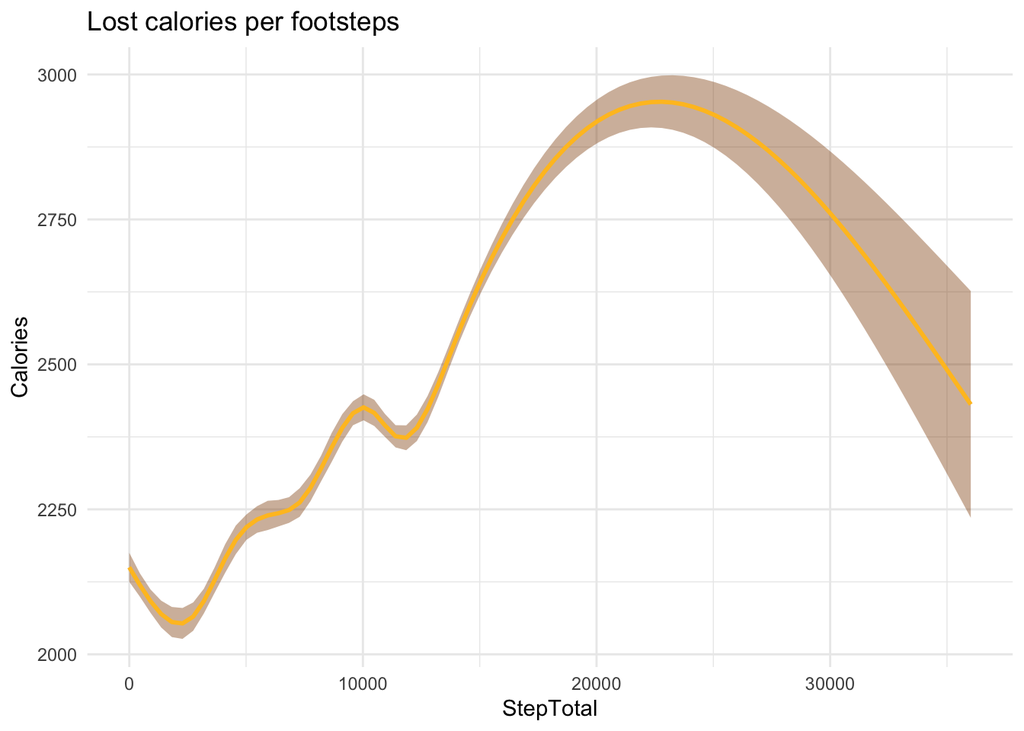

```r
ggplot(data=ad) + geom_smooth(mapping=aes(x=StepTotal,y=Calories),color = "goldenrod1", fill="darkorange4") + labs(title="Lost calories per footsteps", face="italic") + theme_minimal()
```

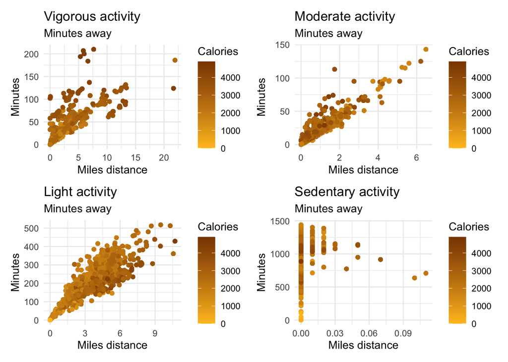

```r
c1 <- ggplot(data=ad, aes(x=VeryActiveDistance, y=VeryActiveMinutes)) + geom_point(aes(color=Calories), alpha=0.5) + scale_color_gradient(low="goldenrod1", high="darkorange4") + labs(title="Vigorous activity", subtitle="Minutes away", y="Minutes", x="Miles distance", face="italic")

c2 <- ggplot(data=ad, aes(x=ModeratelyActiveDistance, y=FairlyActiveMinutes)) + geom_point(aes(color=Calories), alpha=0.5) + scale_color_gradient(low="goldenrod1", high="darkorange4") + labs(title="Moderate activity", subtitle="Minutes away", y="Minutes", x="Miles distance", face="italic")

c3 <- ggplot(data=ad, aes(x=LightActiveDistance, y=LightlyActiveMinutes)) + geom_point(aes(color=Calories), alpha=0.5) + scale_color_gradient(low="goldenrod1", high="darkorange4") + labs(title="Light activity", subtitle="Minutes away", y="Minutes", x="Miles distance", face="italic")

c4 <- ggplot(data=ad, aes(x=SedentaryActiveDistance, y=SedentaryMinutes)) + geom_point(aes(color=Calories), alpha=0.5) + scale_color_gradient(low="goldenrod1", high="darkorange4") + labs(title="Sedentary activity", subtitle="Minutes away", y="Minutes", x="Miles distance", face="italic")

c1 + c2 + c3 + c4 & theme_minimal()
```

### Average

The average lets us know the user’s total steps per day.

```r
dSteps %>%
  group_by(Id) %>%
  summarise(StepTotalAverage = mean(StepTotal))
```

| Id | StepTotalAverage |
| --- | --- |
| 1503960366 | 12116.742 |
| 1624580081 | 5743.903 |
| 1644430081 | 7282.967 |
| 1844505072 | 2580.065 |
| 1927972279 | 916.129 |
| 2022484408 | 11370.645 |
| 2026352035 | 5566.871 |
| 2320127002 | 4716.871 |
| 2347167796 | 9519.667 |
| 2873212765 | 7555.774 |

[output cut: 23 more lines]

## Conclusion

Now, the recommendations that would be given to the Bellabeat team to improve the marketing of their products are as follows: In addition to tracking the physical activity of their users, they also need to gather data on their age, weight, and height. This will enable them to devise a strategy for rewards that motivates users to continue using their products.

## References

I would like to thank the following websites that helped me with create my case:

- Kaggle [Click here](https://www.kaggle.com)
- Coursera [Click here](https://www.coursera.org)
- Stack Overflow [Click here](https://stackoverflow.com)